# **Pan-Cancer - Group 4 (A)**

Jordi Cugat Bardají, Eva Sanz Blasco, Biel Vicente Bou & Kexi Wei

19th of March of 2026

### **1. DATA IMPORTATION**

It is recommended to first upload data set in order to perform the commands after it.

```r
#install.packages("readxl") #If you do not have it

library(readxl)

file <- tempfile(fileext = ".xlsx")

download.file("https://raw.githubusercontent.com/kexi-wei/DV---S1/main/Supplementary_Table_1.xlsx", file, mode = "wb")

S1 <- read_excel(file, skip=2)
```

### **2. DESCRIPTION OF DATA SET**

#### **2.1. Where and why was the information collected?**

The information collected used in this project was extracted from the supplementary table S1 of the research paper called **‘Pan-cancer analysis of whole genomes’** supervised by *Peter J. Campbell, Gad Getz, Jan O. Korbel, Joshua M. Stuart* and *Lincoln D. Stein*.

The experiment aims to better understand the mutations that drive tumors by sequencing whole genomes and including non-coding regions, structural variants, telomere regions… in opposition to the majority of tumor studies which only sequences the coding part of DNA. The information was collected in order to study specific genetic variations along the population which could lead to the development of cancer.

In order to do this, the scientists sequenced thousands of whole genomes and identified and classified each individual mutation. They later categorized them by tumor types amongst other variables.

The data used for the experiment came from big cancer databases such as the International **Cancer Genome Consortium (ICGC)** and **The Cancer Genome Atlas (TCGA)**.

In this case, the data contains 2,658 whole-cancer genomes and their matching normal tissues across 38 tumour types from the **Pan-Cancer Analysis of Whole Genomes (PCAWG)** Consortium of the **International Cancer Genome Consortium (ICGC)** and **The Cancer Genome Atlas (TCGA)**.

#### **2.2. Which is the meaning of each variable?**

- **Tumour_specimen_aliquot_id**: Identifier of the large sample of tumour specimen
- **DCC_specimen_type**: Kind of tumor
- **Gender**: Biological birth sex
- **Age**: Years of the patient at the time
- **Organ_system**: Origin organ of the tumour cells
- **Ancestry_afr**: Proportion of African ancestry
- **Ancestry_asn**: Proportion of Asian ancestry
- **Ancestry_amr**: Proportion of American ancestry
- **Ancestry_san**: Proportion of South Asian ancestry
- **Ancestry_eur**: Proportion of European ancestry
- **Ancestry_primary**: Dominant ancestry
- **Ancestry_primary_contribution**: Percentage contribution of the dominant ancestry
- **Coding.SNVs**: Number of SNVs in coding regions
- **Non.coding.SNVs**: Number of SNVs in non-coding regions
- **Mitochondrial.mutations**: Number of mutations in mitochondrial DNA
- **Tumour_grade**: Degree of tumor aggressiveness
- **Percentage_cellularity**: Percentage of tumour cells in the sample
- **All.SNVs**: Total number of SNVs

#### **2.3. Do the variables have unit? Which one?**

Most of them do not have a unit because they are mostly categories (such as *tumour specimen aliquot id, dcc specimen type, gender, organ system* and *primary ancestry*), but there are a few of them that they do:

- **Age**: Years
- **Ancestry_afr**: Proportion of ancestry between 0-1
- **Ancestry_asn**: Proportion of ancestry between 0-1
- **Ancestry_amr**: Proportion of ancestry between 0-1
- **Ancestry_san**: Proportion of ancestry between 0-1
- **Ancestry_eur**: Proportion of ancestry between 0-1
- **Ancestry_primary_contribution**: Proportion of ancestry between 0-1
- **Coding.SNVs**: Number of mutations
- **Non.coding.SNVs**: Number of mutations
- **Mitochondrial.mutations**: Number of mutations
- **Percentage_cellularity**: Percentage over 100
- **All.SNVs**: Number of SNVs

#### **2.4. Does the data set have a long format?**

For a wide-format data, multiple measurements of a single observation (a single patient) are stored in a row (e.g. *age, ancestry, coding.SNVs*… of the same patient are in one row but different columns).

Whereas for long-format data frames, every single information of an observation/patient is presented in a different row (e.g. *age, ancestry, coding.SNVs*… of the same patient are in different rows). So, taking a look to the data frame we got, it can clearly be seen that the data set does not have a long format, instead, a *wide format* is presented.

### **3. CODING PART**

#### **3.1. Read it into R**

```r
#install.packages("readxl") If you do not have it

library(readxl)

file <- tempfile(fileext = ".xlsx")

download.file("https://raw.githubusercontent.com/kexi-wei/DV---S1/main/Supplementary_Table_1.xlsx", file, mode = "wb")

S1 <- read_excel(file, skip=2, col_names=TRUE, na="NA")
```

```r
S1_shortened <- S1[,c('tumour_specimen_aliquot_id', 'dcc_specimen_type', 'gender', 'age', 'organ_system', 'ancestry_afr', 'ancestry_asn', 'ancestry_amr', 'ancestry_san', 'ancestry_eur', 'ancestry_primary', 'ancestry_primary_contribution', 'Coding.SNVs', 'Non.coding.SNVs', 'Mitochondrial.mutations', 'tumour_grade', 'percentage_cellularity', 'all.SNVs')]
```

#### **3.2. Reshape the data if necessary into long format**

```r
#install.packages("tidyr") If you do not have it
library(tidyr)
id_cols <- c("tumour_specimen_aliquot_id")

long_num <- pivot_longer(
  S1_shortened,
  cols = where(is.numeric) & !all_of(id_cols),
  names_to = "Patient_Information",
  values_to = "Attributes"
)

long_text <- pivot_longer(
  S1_shortened,
  cols = where(is.character) & !all_of(id_cols),
  names_to = "Patient_Information",
  values_to = "Attributes"
)
common_cols <- intersect(names(long_num), names(long_text))

long_num <- long_num[, common_cols]
long_text <- long_text[, common_cols]

long_S1 <- rbind(long_num, long_text)
```

#### **3.3. Check the variable classes and update them if necessary**

```r
str(long_S1) #Every variable matches its variable type, hence, no need to update
```

```
## tibble [43,911 × 3] (S3: tbl_df/tbl/data.frame)
##  $ tumour_specimen_aliquot_id: chr [1:43911] "0009b464-b376-4fbc-8a56-da538269a02f" "0009b464-b376-4fbc-8a56-da538269a02f" "0009b464-b376-4fbc-8a56-da538269a02f" "0009b464-b376-4fbc-8a56-da538269a02f" ...
##  $ Patient_Information       : chr [1:43911] "age" "ancestry_afr" "ancestry_asn" "ancestry_amr" ...
##  $ Attributes                : chr [1:43911] "54" "0.001321176" "1e-04" "1e-04" ...
```

#### **3.4. Explore your data using ggplot2 graphics**

```r
#install.packages("ggplot2")
#install.packages("ggsignif")
library(ggplot2)
library(ggsignif)
```

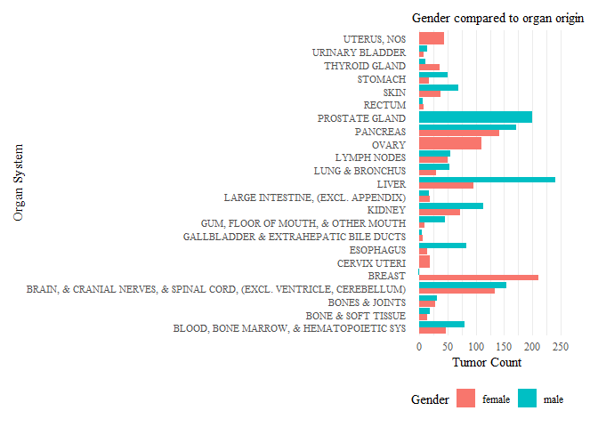

```r
# Where does each gender have more tumors
ggplot(S1_shortened, aes(y = organ_system, fill = gender)) +
  geom_bar(position = "dodge") +
  labs(title = "Gender compared to organ origin",
       x = "Tumor Count",
       y = "Organ System",
       fill = "Gender") +
  theme_minimal() +
  theme(
    text = element_text(family = "serif"),
    axis.text.y = element_text(size = 8),
    legend.position = "bottom",
    panel.grid.major.y = element_blank(),
    panel.grid.minor.y = element_blank(),
    plot.title = element_text(size = 11),
    plot.margin = margin(t = 10, r = 30, b = 10, l = 10)  # adds right space
  )
```

The first thing we wanted to look at in our data was the occurences of the organ systems between the two genders. Thus, we used a **barplot** with the *organ system* variable dividing into **two different columns, one for each gender**. With this, we could take a look to the variation of organ systems in which the tumour is located among males and females and compare it.

As a result, many data can be extracted from the graph. Firstly, we can see that overall, there are **more males with tumors than women**. Secondly, there are organs which seem to be more prone to having tumors, since we see more observations in the graph than others (such as liver, prostate gland, brain…). This, however, **might be due to the sample data and is not representative in the population**. Finally, in some organs, one gender seems to have more tumors than the other. An obvious case here would be breast cancer, which is way more prone in women than in men. However, there are other cases that seem less obvious such as males having more tumors in liver than women. This could be further investigated in order to draw an hypothesis.

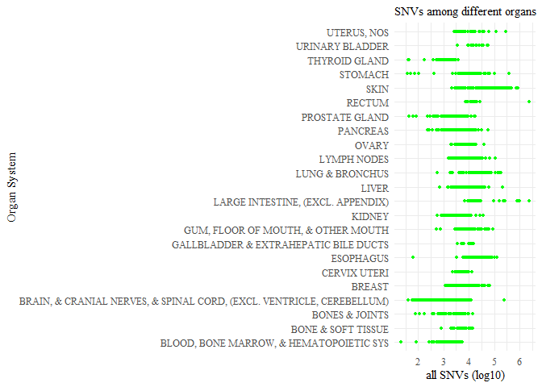

```r
# Which organs get more SNVs
ggplot(S1_shortened, aes(log10(all.SNVs), organ_system)) +
  geom_point(size = 1, colour ='green') +
  labs(title = "SNVs among different organs",
       y = "Organ System",
       x = "all SNVs (log10)") +
  theme_minimal()+
  theme(text = element_text(family = "serif"), plot.title = element_text(size = 11))
```

After showing the variation of the gender variable between organ systems, now we look for the difference in the total number of SNVs among them. To do so, we have used the *geom_point()* function, so that we can see all the SNVs obtained in each patient for each organ.

So, with the plot, we are showing two things: the variability of SNVs **within** each organ system, but also **between** them, as there is a much difference between the SNVs observed in, for example, *Skin* or *Large Intestine* and the SNVs in *Blood, Bone, Marrow & Hematopoietic Sys* or *Thyroid Gland*. The two points with the **more** SNVs are located in *Rectum* and *Large Intestine*, while the **lowest** is in *Blood, Bone, Marrow & Hematopoietic Sys*.

Another important point, is that we can see that some organ-specific tumors have a very **limited range** of SNVs for the tumor to appear and therefore a **consistent mutation level** (e.g. *Gallbladder & Extrahepatic Bile Ducts*). Other organs such as *Stomach* and *Brain*, however, have a **wide** **range** of SNVs observed in patients, making it harder to approximate the number of SNVs that makes a tumor appear.

Also, we can extrapolate that the organs with more points seen towards the **left (less SNVs)** represent tumors that are **easier to get as they need less SNVs** to appear. Therefore, based on this hypothesis, a *Large Intestine* tumor is harder to get while a *Thyroid Gland* tumor is relatively easier to get.

#### **3.5. Represent the distribution of the variables: pick one continuous variable and one discrete variable and use histograms or bar graphs to show their distribution**

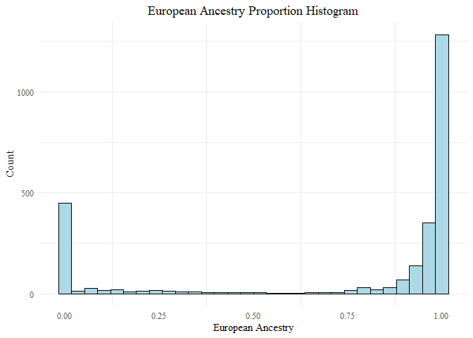

```r
ggplot(S1_shortened, aes(ancestry_eur)) +
  geom_histogram(fill = 'lightblue', colour = 'black', bins = 30, show.legend = FALSE) +
  ggtitle('European Ancestry Proportion Histogram') +
  theme_minimal() +
  theme(text = element_text(family = "serif"),
        panel.grid.major.x = element_blank(),
        plot.title = element_text(hjust = 0.5)) +
  labs(x="European Ancestry", y="Count")
```

The histogram shows a **bimodal distribution** of the *European ancestry* abundance among the patients of the used data. Indeed, the peaks are extremely high, showing **more than a thousand patients with 100% European ancestry** while almost **500 patients have 0% European ancestry**.

This graph is extremely important as it can give us a lot of information about the *origin of the data* of the study which could lead to us thinking whether the whole study is **biased** or not. In this case, it looks like the **vast majority** of the data used comes from **100% European patients**, which we will take into account for the future hypothesis proposed, although, for the simplicity of the project, will not be considered.

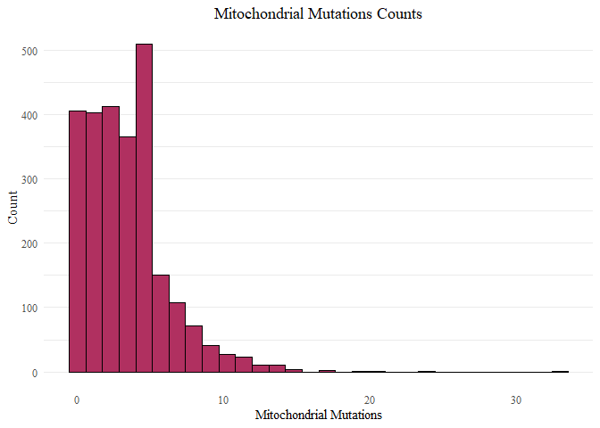

```r
ggplot(S1_shortened, aes(Mitochondrial.mutations)) +
  geom_histogram(fill = 'maroon', colour = 'black') +
  ggtitle('Mitochondrial Mutations Counts') +
  theme_minimal() +
  theme(text = element_text(family = "serif"),
        panel.grid.major.x = element_blank(),
        panel.grid.minor.x = element_blank(),
        plot.title = element_text(hjust = 0.5)) +
  labs(x="Mitochondrial Mutations", y="Count")
```

In the figure above, we can see how many *mitochondrial mutations* the patients had. Seeing how **almost all of the patients had a small number of mitochondrial mutations**, a logical hypothesis would be to assume that **none of the tumors are directly related with mitochondrial tumours** or even that having mitochondrial mutations directly inhibits the formation of tumors.

In the figure above, **an average of 4 mitochondrial mutations** are observed in the data. Another plausible explanation for this distribution could be that a **small amount of mitochondrial mutations is necessary for the formation of a tumour.**

#### **3.6.Summarize the data: use one geom to summarize data (e.g.: geom_smooth, boxplots, …) of two variables**

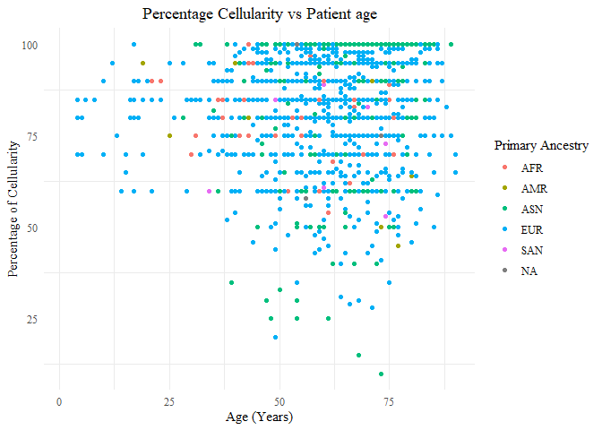

```r
ggplot(S1_shortened, aes(age, percentage_cellularity, colour = ancestry_primary)) +
  geom_point() +
  ggtitle('Percentage Cellularity vs Patient age') +
  theme_minimal() +
  theme(text = element_text(family = "serif"),
        panel.grid.major.y = element_blank(),
        plot.title = element_text(hjust = 0.5)) +
  labs(y="Percentage of Cellularity", x = "Age (Years)", colour = 'Primary Ancestry')
```

The **scatter plot** above shows the mapping of the variables *Percentage Cellularity* and *Age*, coloured by the *Primary Ancestry* of the patient to add further information to it. With this, we intend to explore the diversity of cellularity between the different ages and ancestries.

The results indicate that **independent** from the age, the percentage cellularity is quite **high**. However, some points can be seen below the 50 % above the 30 years age.

#### **3.7. Explain your data with graphics and text**

See part 3.10.

#### **3.8. Choose the three graphics that better describe your data**

See part 3.10.

#### **3.9. Customize and annotate them**

See part 3.10.

#### **3.10.Accompany the figures with your hypothesis and/or interpretation**

**Hypothesis 1.** Males are generally more predisposed to developing tumors of any type than females.

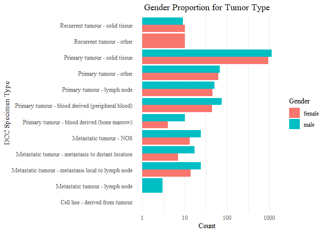

```r
ggplot(S1_shortened, aes(y=dcc_specimen_type, fill=gender)) +
  geom_bar(position="dodge") +
  scale_x_log10() +
  ggtitle("Gender Proportion for Tumor Type") +
  labs(x="Count", y="DCC Specimen Type", fill="Gender") +
  theme_minimal() +
  theme(text = element_text(family = "serif"),
        panel.grid.major.y = element_blank(),
        plot.title = element_text(hjust = 0.5))
```

**Conclusions**

After making a barplot with two different bars (one for males and one for females) for each *DCC specimen type*, we obtain a clear visualization of each *tumour type* and its *gender* frequency. It can be seen that in **almost every type** (apart from recurrent tumours, in which we got opposite results), **males have more tendency to develop any variety of cancer in comparison to females**, although the difference is not quite big.

This leads to the conclusion that males tend to have more tumours **in general**, but the ones having more **recurrency** are females.

**Hypothesis 2.** Following the previous hypothesis, males have higher tendency to develop cancer, which is directly caused by a more number of mutations in their DNA sequence.

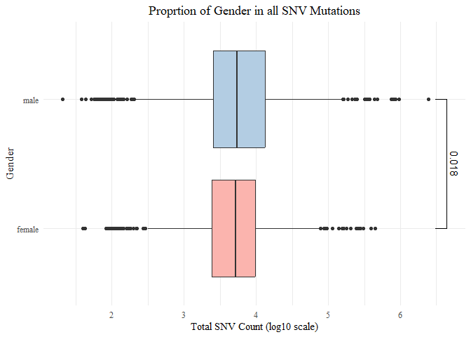

```r
ggplot(S1_shortened, aes(log10(all.SNVs), gender, fill=gender))+
  geom_boxplot() +
  scale_fill_brewer(palette="Pastel1" )+
  labs(x="Total SNV Count (log10 scale)", y="Gender", fill="Gender") +
  ggtitle("Proprtion of Gender in all SNV Mutations") +
  theme_minimal() +
  theme(text = element_text(family = "serif"), legend.position="none", plot.title = element_text(hjust = 0.5)) +
  geom_signif(comparisons = list(c('male','female')), map_signif_level = FALSE)
```

**Conclusions**

To check for the number of mutations in each gender, we have designed a boxplot showing the *total SNVs* in a log10 scale (to reshape the graph such that is more understandable) between the *two genders,* so a statistical difference is **distinguishable**. In addition, we have added the **significance level** of the variables.

As we can observe, the females’ box plot is slightly more **shifted to the left**, meaning that statistically, they have **less SNV than males**. Furthermore, taking a look to the **p-value (0.018)** shown in the plot, it can be stated that this difference is **significant**, such that **males are indeed also more probable to experiment more mutations in the DNA.**

Biologically, this could be extremely linked to the previous hypothesis, as cancerigenous tissues are caused precisely by mutations on its cells, which leads to cancer. Therefore, as males are generally statistically more **probable** to have a mutation, it is reasonable to expect that they also have **prevalence** to develop most types cancer.

**Hypothesis 3.** Age is extremely related to SNV mutations, hence, older patients will tend to have more mutations than a younger one.

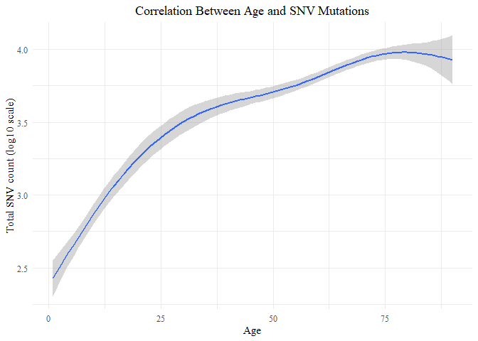

```r
ggplot(S1_shortened, aes(age, log10(all.SNVs))) +
  geom_smooth() +
  labs(x="Age", y="Total SNV count (log10 scale)") +
  ggtitle("Correlation Between Age and SNV Mutations") +
  theme_minimal() +
  theme(text = element_text(family = "serif"), plot.title = element_text(hjust = 0.5))
```

```r
cor.test(S1_shortened$age, log10(S1_shortened$all.SNVs))
```

```
##
##  Pearson's product-moment correlation
##
## data:  S1_shortened$age and log10(S1_shortened$all.SNVs)
## t = 29.976, df = 2552, p-value < 2.2e-16
## alternative hypothesis: true correlation is not equal to 0
## 95 percent confidence interval:
##  0.4810337 0.5384280
## sample estimates:
##       cor
## 0.5102988
```

**Conclusions**

In order to test our hypothesis, we have done a **correlation plot** between *age* and the *total SNVs* observed in a log10 scale to adjust the size.

By focusing on a **biological** explenation, this statement makes sense because of the **cumulative sum** of various mutated DNA replication, **declining repair** mechanisms due to **aging**, and increased **oxidative stress**; all of them increase along the years and contribute to the total count of mutations.